# ICE IVIVE workflow

# Description

The workflow allows the flexibility to select from five different rat and human PK models: a one-compartment model that incorporates Monte Carlo simulation to simulate the population variance (1c), and four models leveraging the [EPA’s httk package](https://github.com/USEPA/CompTox-ExpoCast-httk) which include a 3 compartment model (solve_3comp), a multi-compartment PBPK model for modeling oral and i.v. exposure (solve_pbtk), a multi-compartment PBPK model for modeling inhalation (gas) route of exposure (solve_gas_pbtk), and a multi-compartment human PBPK model that includes both maternal and fetal compartments, and a placenta modeled as a joint organ shared by mother and fetus (solve_fetal_pbtk). The workflow is to predict the equivalent administered dose (EAD) that would lead to steady state plasma concentration or maximum plasma concentration (Cmax) equal to the bioactive concentration from in vitro assays. For inhalation exposures using the (solve_gas_pbtk) EAD is generated in uM or ppmv if using”concentration” exposure vs a dose.

Two example files are included: * ChemicalData_Rnotebook.txt * InvitroData_Rnotebookv.txt

# Load libraries

```r
#load libraries
library(tidyverse)   #needed for read-delim()
library(deSolve)
library(doParallel)
library(httk)        #this is needed for models: solve_3comp, solve_pbtk, solve_gas_pbtk, solve_fetal_pbtk
                     #The code is compatible with httk_2.2.2
library(readxl)      #for read_excel() #2025
#library(xlsx)        #for writing the excel file that is user output
date <- format(Sys.Date(), format="%y%m%d") #added to add information on date
```

# Input data and output file path

There are several input variables needed to run the code. Some variables are model specific, as detailed. Adjust the file paths to point to the file in your directory.

chemFile: the file containing chemical data from ICE. this has the CASRN as the first field assayFile: the file with the in vitro bioactivity data. The first column is the CASRN and the subsequent columns are the bioactivity values output_file: this is the file for the outputs

```r
chemFile <- "ChemicalData_Rnotebook.txt" #chemicals data from ICE, include CASRN field as identifier
assayFile <- "invitroData_Rnotebook.txt" #invitro data from ICE, includes CASRN field as identifier then acc/ac50
#chemFile <- "Template_ICEData.txt"
#assayFile <- "InvitroData_Rnotebook_10chem.txt"
Userout <- "User_Results.xlsx"           #file name (and path) for the output file for the tissue; concentrations with EAD estimations along with the in vitro data
EADplot_file <-"User_plot.pdf"           #the file for the plot of the EAD plot
invivo <- NULL                           #invivo data provided by user
#invivoFile <- "InvivoData_Rnotebook.txt"
#invivo <- as.data.frame(read_delim(invivoFile, delim = "\t"))
```

# Model variables

Details about what model, route, and dose need to be specified. There are differences in what is needed if a 1 compartment model is used vs the PBPK models

# What model?

Models type is limited to 5 different models. Currently, species in ICE is limited to human or rat. Using this notebook one can expand the species with minor editing of the code provided the parameters are available.

```r
targetTissue <- 'Cplasma'                                                                                     #2025
  #1c: 'Cplasma'                                                                                              #2025
  #solve_3comp: 'Cplasma', 'Cliver'                                                                           #2025
  #solve_pbtk: 'Cplasma', 'Cliver', 'Cgut', 'Clung', 'Ckidney', 'Crest'                                       #2025
 #solve_gas_pbtk: 'Cplasma', 'Cliver', 'Cgut', 'Clung', 'Ckidney', 'Cmuc', 'Crest'                            #2025
  #solve_fetal_pbtk: 'Cplasma', 'Cliver', 'Cgut', 'Clung', 'Ckidney', 'Cadipose', 'Crest', 'Cplacenta',       #2025
targetTissue_fetal <- 'Cfplasma'                                                                              #2025
  #solve_fetal_pbtk: 'Cfplasma', 'Cfliver', 'Cfgut', 'Cflung', 'Cfkidney', 'Cfbrain', 'Cfthyroid', 'Cfrest'   #2025
species <- "human"                       #human or rat
bWeight <- 70                            #the body weight of simulated subject
modelType <-  "1c"         #"1c", solve_3comp", "solve_pbtk", "solve_gas_pbtk", "solve_fetal_pbtk"; only 1c is capitalized.
```

For the 1 compartment model, values are needed to parameterize the Monte Carlo simulation.

```r
nsamples <- 300                          #user-provided value for the mc simulations, any number between 10 - 10,000
```

For the PBPK models some additional parameters can be modified. An inhalation exposure has additional parameters The route determines where the chemical will enter the system and route, interval, and days are needed for all PBPK models.

```r
route <- "oral"                          #oral, iv, or inhalation needed for PBPK models; "solve_gas_pbtk" uses the inhalation route
interv <- 24                             #dosing interval, hours
ndays <- 3                               #number of days dosing is done
expDose <- 1                             #current calculations assume 1mg/kg/dose for "1c", "solve_3comp", "solve_pbtk", "solve_fetal_pbtk".
expConc <- 1                             #Dosing for "solve_gas_pbtk" model
ConcentrationUnit <- "uM"                #Renamed as Output Conc. Units in PBPK tool since ICE4.0. Options are uM and mg/L, but this is not available option for the ICE UI since the unit for in vitro activity concentration provided in ICE is uM; The user need to make sure
                                         #the unit for in vitro activity concentration is consistent with the "ConcentrationUnit" they select.
gestationDays <- 91                      #gestational days when dose starts, range is 91 days (14 weeks) -  280 days (40 weeks)
```

# Inhalation specific parameters

For an inhalation route of exposure, there are 2 different ways that the exposure can be modeled. “expDose” models a set bolus dose like the exposure for an oral or IV exposure. The “expConc” is more typical of a gas exposure. This models an inhaled concentration over a duration of time, set by “expLength”. The “expDose” option is currently unavailable.

```r
gasDosing <-"expConc"                    #two dosing option methods for solve_gas_pbtk model, "expConc" and "expDose",
                                         #but for ICE3.3 release, "expConc" is the only option due to a bug found in httk function
                                         #This is only needed if gasDosing =="expConc" because otherwise default to expDose
if(gasDosing =="expConc" & (!exists("expConc") || is.null(expConc))){
  expConc <- 1                           #current calculations assume 1uM of air concentration
}
gasInputUnit <- "ppmv"                   #Input concentration unit for gas model (httkv2.1.0 and later), "uM" or "ppmv" (default)
expLength <- 0.25                         #length of the gas exposure, hours
```

# Gestation model specific parameters

```r
gestationDays <- 91                #gestation model specific parameter;gestational days when dose starts, range is 91 days (14 weeks) -  280 days (40 weeks)
```

# Argument for EADboxplot.R

```r
chemDisplay <- "ChemicalName"            #choice is "CASRN" or "ChemicalName"
if(modelType != "solve_gas_pbtk"){       #"mg/kg/dose" for "1c", "solve_3comp", "solve_pbtk"; uM or ppmv for "solve_gas_pbpk" model
  EADUnit <- "mg/kg/dose"
}else{EADUnit <- gasInputUnit}
```

# Load functions

```r
source("steadyState.R")                  #All required R scripts and input files should be in the working directory; required for "1c" model
source("CalcEAD.R")                      #required for "1c", "solve_3comp", "solve_pbtk", "solve_gas_pbpk" models
source("EADboxplot.R")
```

# Load data

Notice that the chem input has the source of the FU and Clint data. ICE now has 2 different sources of these values so the source is important for tracking this information.

```r
#there are single quotes in chemical names that need to be addressed, the tidyR handles well
#chemical <- as.data.frame(read_delim(chemFile, delim = "\t"))
chemical <- as.data.frame(read_delim(chemFile, trim_ws = TRUE,na = c("", "NA"), delim = "\t",quote = "\""))
#chemical[1:2,]
```

```r
#invitro <- as.data.frame(read_delim(assayFile, delim = "\t"))
invitro <- as.data.frame(read_delim(assayFile, trim_ws = TRUE,na = c("", "NA"), delim = "\t",quote = "\""))
invitro <- semi_join(invitro, chemical, by = "CASRN")                                  #2025
#invitro[1:2,]
```

# Preparing data

Minor prep work is done on the data that comes from ICE Partitioning coefficients are obtained by internal function from the httk package using the provided phys chem parameters. Compare with the example input file for naming Note that a few checks are done. These will generate flags that can be used to follow up as needed.

```r
##load data
chemical <- as.data.frame(read_delim(chemFile, trim_ws = TRUE,na = c("", "NA"), delim = "\t",quote = "\"")) #there are single quotes in chemical names that need to be addressed
invitro <- as.data.frame(read_delim(assayFile, trim_ws = TRUE,na = c("", "NA"), delim = "\t",quote = "\""))
invitro <- semi_join(invitro, chemical, by = "CASRN")                                  #2025

##column names should be labeled correctly, see the example file
##cleaning the names for taking from an ICE Query-stricter matching is used to handel including the ADME source information
colnames(chemical)<-gsub(".*Name.*", "ChemicalName", colnames(chemical))
colnames(chemical)<-gsub(".*Parameters fu.*", "fu", colnames(chemical), ignore.case =TRUE)
colnames(chemical)<-gsub(".*funbound.*", "fu", colnames(chemical), ignore.case =TRUE)
colnames(chemical)<-gsub(".*fu Source.*", "fu Source", colnames(chemical), ignore.case =TRUE)
colnames(chemical)<-gsub(".*MW.*", "MW", colnames(chemical))
colnames(chemical)<-gsub(".*HL.*", "HL", colnames(chemical))
colnames(chemical)<-gsub(".*Parameters Clint.*", "Clint", colnames(chemical), ignore.case = TRUE)
colnames(chemical)<-gsub(".*Clint Source.*", "Clint Source", colnames(chemical), ignore.case = TRUE)
colnames(chemical)<-gsub(".*LogP.*", "LogP", colnames(chemical))
colnames(chemical)<-gsub(".*pKa, Basic.*", "pka_Accept", colnames(chemical))
colnames(chemical)<-gsub(".*pKa, Acidic.*", "pka_Donor", colnames(chemical))

#Converting units for internsic clearance values
#this moves from log10 ul/ml/10^6 cells to just ul/ml/10^6 cells
#chemical$Clint<-10^chemical$Clint
chemical$logPwa<--1*(chemical$HL+1.61) #this gets the water-air partition coefficient, as the unit for HL from OPERA is (LogHL,atm-m^3/mole),logaw=logHL-logRT=logHL-log(0.0244)for T=298.15K  #2025 #Add the flag here as a warning if model not appropriate or other issues related to generating predictions for a chemical
chemical$Flag <-""
#catch for low Fu
chemical$Flag[chemical$fu<=1e-10]<-"fu is zero,likely due to rounding. Setting to 1e-5"
chemical$fu[chemical$fu<=1e-10]<-1e-5
```

# 1c modeling

If modelType given by the user is “1c” This will run a simple, 1 compartment model. In this model the C steady state is determined vs the Cmax from the other models.

# Calculating the EADs

The 1c model has a monte carlo simulation that calculates the Css at the 50th and the 95th percentile The first step is generating the CSS object with the call to “steadState”.

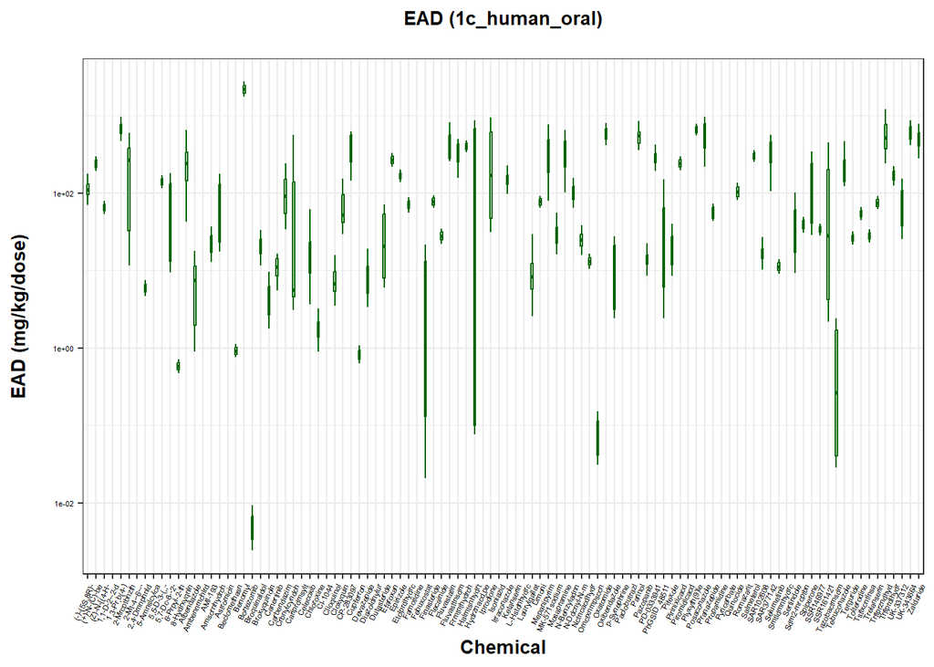

```r
### starting to model
p.out_all <- NULL

### model "1c"
if(modelType == "1c"){
  chemInput <- chemical
  #chemInput <- chemical[,c("CASRN", "ChemicalName", "Clint", "fu", "MW", "Flag")]
  set.seed(1234)
  CSS<- steadyState(inputData = chemInput, nsamples = nsamples, species = species, ConcentrationUnit = ConcentrationUnit)
  head(CSS)

  #There are 2 different steady state predictions, 50 and 95 percentile.
  #The EAD is calculated for each using the "CalcEAD" function. The data is then formated into a single data object

  EAD.out50 <- CalcEAD(Css = CSS[,c("CASRN", "50%", "fu")], inVitro = invitro, adj.fu = "fu")
  colnames(EAD.out50)<-gsub("EAD","EAD.50", colnames(EAD.out50))
  #add in the flag column
  EAD.out50<-left_join(chemInput[,c("CASRN","Flag")],EAD.out50)
  EAD.out95 <- CalcEAD(Css = CSS[,c("CASRN","95%", "fu")], inVitro = invitro, adj.fu = "fu")
  colnames(EAD.out95)<-gsub("EAD","EAD.95", colnames(EAD.out95))
  EAD.out<-left_join(EAD.out50,EAD.out95)
  EAD.out<-EAD.out[,setdiff(colnames(EAD.out), c("adj.fu", "fu", "adj.arm","arm"))] # remove the columns "fu", adj.fu","adj.arm" and "arm"
  #creating output file for user, should have EAD values and the parameters for calculating the circulating concentration
  CSS2<-as.data.frame(CSS, stringsAsFactors=FALSE); colnames(CSS2)<-gsub("50%", "Css, 50%ile", colnames(CSS2)); colnames(CSS2)<-gsub("95%", "Css, 95%ile", colnames(CSS2))
  CSS2$Species<-species; CSS2$Model<-modelType; CSS2$"Dose, mg/kg"<-expDose;CSS2$Route<-route
  CSS2$nSimulations <- nsamples
  colnames(CSS2)<-gsub("Css_Unit","Css, Units", colnames(CSS2))

  CSS2<-left_join(CSS2, chemical %>% select(any_of( c("CASRN","Clint Source", "fu Source"))))

  #reformatting columns to match the other models:
  CSS2<-CSS2 %>% select(any_of(c("CASRN", "ChemicalName", "Css, 50%ile", "Css, 95%ile", "Css, Units", "Flag", "Species", "Model", "Route", "Dose, mg/kg", "Clint", "Clint Source", "Clint_InputSource", "fu", "fu Source", "fu_InputSource", "MW", "MW_InputSource", "LogP", "LogP_InputSource", "HL", "HL_InputSource", "pka_Accept", "pka_Accept_InputSource", "pka_Donor", "pka_Donor_InputSource")))  #2025June
  ssEAD.out<-EAD.out[,c("CASRN", setdiff(colnames(EAD.out), c(colnames(invitro), "50%","95%")))]
  outputData<-full_join(CSS2,ssEAD.out)
  colnames(outputData)<-gsub("Clint$", "Clint, ul/ml/10^6 cells", colnames(outputData))#add units
  p.out_all <- CSS2 %>% select(any_of(c("CASRN", "ChemicalName", "LogP", "LogP_InputSource", "Clint", "Clint Source", "Clint_InputSource", "fu", "fu Source", "fu_InputSource", "pka_Donor", "pka_Donor_InputSource", "pka_Accept", "pka_Accept_InputSource", "HL", "HL_InputSource", "MW", "MW_InputSource", "Flag")))  #2025June
  p.out_all<- p.out_all %>% rename("Log of Henry’s Law constant" = "HL")

  #The output file is an excel workbook. This has 2 tabs, one for the EAD results and the other for the invitro data
  xlsx::write.xlsx(file=Userout, x=outputData, sheetName ="EADResults", append=FALSE, row.names = FALSE, showNA = FALSE) #starting a new book
  xlsx::write.xlsx(file=Userout, x=invitro, sheetName ="inVitroData", append=TRUE, row.names = FALSE, showNA = FALSE)    #adding in vitro data
  xlsx::write.xlsx(file=Userout, x=p.out_all, sheetName ="PKparameters", append=TRUE, row.names = FALSE, showNA = FALSE) #adding parameters for populating PK/PBPK models

  #To view the results, the "EADboxplot" function plots the values.
  EADplot <- EADboxplot(EAD.out = outputData, invivo = invivo, label="EAD", EADUnit = EADUnit, species = species, route = route, modelType = modelType, chemDisplay = chemDisplay, axis.text=4)
  #Arguments for EADplot functions include "EAD.out, invivo, label, chemDisplay, EADUnit, modelType, species, route, date, doses.per.day, wth, axis.text, title.text, shape.size, dpi"
  EADplot
 }
```

# script to run pbpk models from httk package

This code is used if modelType given by the user is a PBPK model: “solve_3comp”, “solve_pbtk”, “solve_gas_pbpk”, or “solve_fetal_pbtk. This is wrapper code to format the inputs and parameters needed to run the models specified by the httk package. In addition, the output is formatted so that it matches the 1c model. This allows easy comparison between the different files for subsequent processing.

## Parameter processing for the pbpk models

The httk package needs some additional parameters including the correct capitalization of the species and ensuring that the adding of the user-specified data to the chem table is properly integrated.

```r
if(modelType %in% c("solve_3comp", "solve_pbtk", "solve_gas_pbtk", "solve_fetal_pbtk")){
  # preprocessing variables:
  if (tolower(species) == "rat") {
    species_1 <- "Rat"
  }
  if (tolower(species) == "human") {
    species_1 <- "Human"
  }
  options(stringsAsFactors = FALSE)
  # add chemical info to the table. Using variable coming from ICE
  # to deal with mapping issues
  chemical$DTXSID2<-paste0(chemical$DTXSID, "_n")
  if(species_1=="Human"){
    chem.physical_and_invitro.data <- add_chemtable(chemical, current.table = chem.physical_and_invitro.data, data.list = list( CAS = "CASRN",DTXSID="DTXSID2",Clint = "Clint", Funbound.plasma = "fu",  pKa_Donor = 'pka_Donor', pKa_Accept = 'pka_Accept', logP = "LogP", logPwa = "logPwa", MW = "MW", logHenry="HL"), species = species_1, reference = paste0(species_1, "ICE"), overwrite = T)
  }else{
    chem.physical_and_invitro.data <- add_chemtable(chemical, current.table = chem.physical_and_invitro.data, data.list = list( CAS = "CASRN",DTXSID="DTXSID2",Clint = "Clint", Funbound.plasma = "fu",  pKa_Donor = 'pka_Donor', pKa_Accept = 'pka_Accept', logP = "LogP", logPwa = "logPwa", MW = "MW", logHenry="HL"), species = species_1, reference = paste0(species_1, "ICE"), overwrite = T)
    chem.physical_and_invitro.data <- add_chemtable(chemical, current.table = chem.physical_and_invitro.data, data.list = list( CAS = "CASRN",DTXSID="DTXSID2",Clint = "Clint", Funbound.plasma = "fu"), species = "Human", reference = paste0(species_1, "ICE"), overwrite = T) #addresses bug issues where look up from human bc assume no rat
  }

# to allow the user to change the body weight for rat and human
  if(species_1=="Human"){
    physiology.data[4,6] <- bWeight
  }else{
    physiology.data[4,4] <- bWeight #Average rat body weight,changed from [2,6] to [4,4]
  }

if(route != "iv"){
  iv.dose = FALSE
}else{iv.dose =TRUE}

dpd <- 24/interv #calculating the doses per day
cmaxall <- NULL
}
```

# solve_3comp model

The [solve_3comp](https://rdrr.io/cran/httk/man/solve_3comp.html) model is a 3 compartment model that has the gut,gut lumen, liver, and rest of the body compartments with the plasma equivalent to the liver plasma concentrations.

```r
# note that dose=0 stops the initial dosing of the compartments and is needed to accurately model the specified dosing situation
if(modelType == "solve_3comp"){
  for(this.cas in chemical[,"CASRN"]) {
    set.seed(1234)
    Kliver2pu  <- chemical$Kliver2pu[chemical$CASRN == this.cas]
    Krest2pu   <- chemical$Krest2pu[chemical$CASRN == this.cas]
    Kgut2pu    <- chemical$Kgut2pu[chemical$CASRN == this.cas]
    param <- parameterize_3comp(chem.cas = this.cas, species = species_1, default.to.human = TRUE)
    print(param$BW)  # to make sure that the body weight had been changed.
    param$Kliver2pu <- ifelse(!is.na(Kliver2pu), Kliver2pu , param$Kliver2pu)            #2025June
    param$Kliver2pu_Source <- ifelse(!is.na(Kliver2pu), "CUSTOM", "httkCalculated")      #2025June
    param$Krest2pu <- ifelse(!is.na(Krest2pu), Krest2pu, param$Krest2pu)                 #2025June
    param$Krest2pu_Source <- ifelse(!is.na(Krest2pu), "CUSTOM", "httkCalculated")        #2025June
    param$Kgut2pu <- ifelse(!is.na(Kgut2pu), Kgut2pu, param$Kgut2pu)                     #2025June
    param$Kgut2pu_Source <- ifelse(!is.na(Kgut2pu), "CUSTOM", "httkCalculated")          #2025June
    p.out0 <- as.data.frame(param)       #automatically resets row names       #for output #2025
    colnames(p.out0) <- paste0("ModelParam_", colnames(p.out0))                #for output #2025
    rownames(p.out0)<- this.cas                                                #for output #2025
    p.out <- rownames_to_column(p.out0, var = "CASRN")                         #for output #2025
    concMax <- max(solve_3comp(chem.cas = this.cas, parameters = param, doses.per.day = dpd, days = ndays, tsteps = 4, dose=0, daily.dose = expDose*dpd, iv.dose = iv.dose, output.units = ConcentrationUnit, species = species_1, default.to.human = TRUE, plots = F, suppress.messages = TRUE)[,targetTissue])
    cmax_temp <- as.data.frame(cbind(this.cas, concMax, ConcentrationUnit))
    cmaxall <- rbind(cmaxall, cmax_temp)
    p.out_all <- rbind(p.out_all, p.out)    #2025
  }
}
```

# solve_pbtk model

the [solve_pbtk](https://rdrr.io/cran/httk/man/solve_pbtk.html) model is a PBPK model that has gutlumen, gut, liver, kidneys, veins, arteries, lungs, and the rest of the body compartments.

```r
if(modelType == "solve_pbtk"){
  for(this.cas in chemical[,"CASRN"]) {
      set.seed(1234)
      Kkidney2pu <- chemical$Kkidney2pu[chemical$CASRN == this.cas]
      Kliver2pu  <- chemical$Kliver2pu[chemical$CASRN == this.cas]
      Krest2pu   <- chemical$Krest2pu[chemical$CASRN == this.cas]
      Kgut2pu    <- chemical$Kgut2pu[chemical$CASRN == this.cas]
      param <- parameterize_pbtk(chem.cas = this.cas, species = species_1, default.to.human = TRUE)
      print(param$BW)  # to make sure that the body weight had been changed.
      param$Kkidney2pu <- ifelse(!is.na(Kkidney2pu), Kkidney2pu, param$Kkidney2pu)         #2025June
      param$Kkidney2pu_Source <- ifelse(!is.na(Kkidney2pu), "CUSTOM", "httkCalculated")    #2025June
      param$Kliver2pu <- ifelse(!is.na(Kliver2pu), Kliver2pu , param$Kliver2pu )          #2025June
      param$Kliver2pu_Source <- ifelse(!is.na(Kliver2pu), "CUSTOM", "httkCalculated")    #2025June
      param$Krest2pu <- ifelse(!is.na(Krest2pu), Krest2pu, param$Krest2pu)                 #2025June
      param$Krest2pu_Source <- ifelse(!is.na(Krest2pu), "CUSTOM", "httkCalculated")        #2025June
      param$Kgut2pu <- ifelse(!is.na(Kgut2pu), Kgut2pu, param$Kgut2pu)                     #2025June
      param$Kgut2pu_Source <- ifelse(!is.na(Kgut2pu), "CUSTOM", "httkCalculated")          #2025June
      p.out0 <- as.data.frame(param)       #automatically resets row names       #for output #2025
      colnames(p.out0) <- paste0("ModelParam_", colnames(p.out0))                #for output #2025
      rownames(p.out0)<- this.cas                                                #for output #2025
      p.out <- rownames_to_column(p.out0, var = "CASRN")                         #for output #2025
      output0 <- solve_pbtk(chem.cas = this.cas, parameters = param, doses.per.day = dpd, days = ndays, dose=0, daily.dose = expDose*dpd, iv.dose = iv.dose, output.units = ConcentrationUnit, species = species_1, default.to.human = TRUE, plots = F, suppress.messages = TRUE)
      trim_output <- as.data.frame(output0) #store output

      if(route =="iv"){
        #ignore possible computational errors
        to_ignore <- 2 #<- time point 2 will always be anomalous
       n_to_ignore <- max(1,floor((24*ndays)/interv))
        if((24/interv) == 1){
          steps_between_doses <- 97
        }else if(24/interv > 1){
          steps_between_doses <- floor(97 / (24/interv))+1
        }else if(24/interv < 1){
          steps_between_doses <- floor(97 / (24/interv))
        }
        for(i in 1:n_to_ignore){
          to_ignore[i+1] = to_ignore[i] + steps_between_doses
        }
        trim_output <- trim_output[-to_ignore,]
      }

      concMax <-max(trim_output[,targetTissue])
      cmax_temp <- as.data.frame(cbind(this.cas, concMax, ConcentrationUnit))
      cmaxall <- rbind(cmaxall, cmax_temp)
      p.out_all <- rbind(p.out_all, p.out)    #2025
  }
 }
```

# solve_gas_pbtk model

The [solve_gas_pbtk](https://rdrr.io/cran/httk/man/solve_gas_pbtk.html) is a PBPK model similar to the “solve_pbtk” model but is uses an inhalation route of exposure assuming the chemical is volatile (gas). As a result, it has some addtional checks to see if the assumption of gas exposure is reasonable but will still proceed with a flag warning. It also includes 2 different dosing approaches, a concentration over time (expConc) or a single dose (expDose)

```r
if(modelType == "solve_gas_pbtk"){
  #check the assumption of volatility
  chemical$Flag[chemical$HL <= -7.80388 & chemical$Flag!=""] <-"fu is zero,likely due to rounding. Setting to 1e-5; Chemical likely nonvolatile, consider appropriateness of model"
  chemical$Flag[chemical$HL <= -7.80388 & chemical$Flag==""] <-"Chemical likely nonvolatile, consider appropriateness of model"

  for(this.cas in chemical[,"CASRN"]) {
    set.seed(1234)
    Kkidney2pu <- chemical$Kkidney2pu[chemical$CASRN == this.cas]
    Kliver2pu  <- chemical$Kliver2pu[chemical$CASRN == this.cas]
    Krest2pu   <- chemical$Krest2pu[chemical$CASRN == this.cas]
    Kgut2pu    <- chemical$Kgut2pu[chemical$CASRN == this.cas]
    # --- expDose option has currently been disabled due to a bug in the httk package ---
    # if(modelType=="solve_gas_pbtk" & gasDosing == "expDose"){
    #   ConcentrationUnit <- "uM"  # output unit only has one option of "uM" for solve_gas_pbtk model
    #   concMax <- max(solve_gas_pbtk(chem.cas = this.cas, parameters = NULL, doses.per.day = dpd, days = ndays, tsteps = 4, dose=0, daily.dose = expDose*dpd, exp.conc = 0, period=interv, exp.duration = expLength, output.units = ConcentrationUnit, species = species_1, default.to.human = TRUE, plots = F, suppress.messages = TRUE)[,targetTissue])
    # }

    if(gasDosing == "expConc"){
      param <- parameterize_gas_pbtk(chem.cas = this.cas, species = species_1, default.to.human = TRUE)
      print(param$BW)  # to make sure that the body weight had been changed.
      param$Kkidney2pu <- ifelse(!is.na(Kkidney2pu), Kkidney2pu, param$Kkidney2pu)         #2025June
      param$Kkidney2pu_Source <- ifelse(!is.na(Kkidney2pu), "CUSTOM", "httkCalculated")    #2025June
      param$Kliver2pu <- ifelse(!is.na(Kliver2pu), Kliver2pu , param$Kliver2pu )           #2025June
      param$Kliver2pu_Source <- ifelse(!is.na(Kliver2pu), "CUSTOM", "httkCalculated")      #2025June
      param$Krest2pu <- ifelse(!is.na(Krest2pu), Krest2pu, param$Krest2pu)                 #2025June
      param$Krest2pu_Source <- ifelse(!is.na(Krest2pu), "CUSTOM", "httkCalculated")        #2025June
      param$Kgut2pu <- ifelse(!is.na(Kgut2pu), Kgut2pu, param$Kgut2pu)                     #2025June
      param$Kgut2pu_Source <- ifelse(!is.na(Kgut2pu), "CUSTOM", "httkCalculated")          #2025June
      p.out0 <- as.data.frame(param)       #automatically resets row names       #for output #2025
      colnames(p.out0) <- paste0("ModelParam_", colnames(p.out0))                #for output #2025
      rownames(p.out0)<- this.cas                                                #for output #2025
      p.out <- rownames_to_column(p.out0, var = "CASRN")                         #for output #2025
      concMax <- max(solve_gas_pbtk(chem.cas = this.cas, parameters = param, doses.per.day = NULL, days = ndays, dose = NULL, daily.dose = NULL, exp.conc = expConc,  input.units = gasInputUnit, period=interv, exp.duration = expLength, output.units = ConcentrationUnit, species = species_1, default.to.human = TRUE, plots = F, adjusted.Funbound.plasma = TRUE, suppress.messages = TRUE)[,targetTissue])
      #note for v2.2.2, must specify total "daily.dose" when "doses.per.day" is not set to NULL.
    }
    cmax_temp <- as.data.frame(cbind(this.cas, concMax, ConcentrationUnit))
    cmaxall <- rbind(cmaxall,cmax_temp)
    p.out_all <- rbind(p.out_all, p.out)    #2025
  }
}
```

# solve_fetal_pbtk model

The [solve_fetal_pbtk](https://rdrr.io/cran/httk/man/solve_fetal_pbtk.html) is a human PBPK model that includes both maternal and fetal compartments and a placenta modeled as a joint organ shared by mother and fetus. It simulated gestation day of 91-280 days. A flag warning will show if the gestation day is out of this range. The exposure routes for this model are oral and IV.

```r
if(modelType == "solve_fetal_pbtk"){
  if(species_1 != "Human"){
      stop("Gestation model is for human only")
  }
  if(gestationDays < 91 || gestationDays > 280) {
    print("Warning: the gestation day is the day when dosing starts, which shall be within the range of 91-280 days")
  }

  for(this.cas in chemical[,"CASRN"]) {
     set.seed(1234)
     Kkidney2pu <- chemical$Kkidney2pu[chemical$CASRN == this.cas]
     Kliver2pu  <- chemical$Kliver2pu[chemical$CASRN == this.cas]
     Krest2pu   <- chemical$Krest2pu[chemical$CASRN == this.cas]
     Kgut2pu    <- chemical$Kgut2pu[chemical$CASRN == this.cas]
     param <- parameterize_fetal_pbtk(chem.cas = this.cas, species = "human", default.to.human = TRUE)
     print(param$BW)  # to make sure that the body weight had been changed
     param$Kkidney2pu <- ifelse(!is.na(Kkidney2pu), Kkidney2pu, param$Kkidney2pu)         #2025June
     param$Kkidney2pu_Source <- ifelse(!is.na(Kkidney2pu), "CUSTOM", "httkCalculated")    #2025June
     param$Kliver2pu <- ifelse(!is.na(Kliver2pu), Kliver2pu , param$Kliver2pu )          #2025June
     param$Kliver2pu_Source <- ifelse(!is.na(Kliver2pu), "CUSTOM", "httkCalculated")    #2025June
     param$Krest2pu <- ifelse(!is.na(Krest2pu), Krest2pu, param$Krest2pu)                 #2025June
     param$Krest2pu_Source <- ifelse(!is.na(Krest2pu), "CUSTOM", "httkCalculated")        #2025June
     param$Kgut2pu <- ifelse(!is.na(Kgut2pu), Kgut2pu, param$Kgut2pu)                     #2025June
     param$Kgut2pu_Source <- ifelse(!is.na(Kgut2pu), "CUSTOM", "httkCalculated")          #2025June
     p.out0 <- as.data.frame(param)       #automatically resets row names  #for output #2025
     colnames(p.out0) <- paste0("ModelParam_", colnames(p.out0))           #for output #2025
     rownames(p.out0)<- this.cas                                           #for output #2025
     p.out <- rownames_to_column(p.out0, var = "CASRN")                    #for output #2025


      output0  <- solve_fetal_pbtk(chem.cas = this.cas, parameters = param, times=seq(gestationDays, gestationDays+ndays, 0.025), doses.per.day = dpd, dose= NULL, daily.dose = expDose*dpd, iv.dose = iv.dose, output.units = ConcentrationUnit, species = "human", default.to.human = TRUE, plots = FALSE, suppress.messages = TRUE) #note - httk v2.1.0 and later, species = "human" is the default
      #initial.values = NULL; #times: time sequence in days. Default is from 13th week of pregnancy to 40th week due to data constraints; times = seq(13 * 7, 40 * 7, 1)
      #store output
      trim_output <- as.data.frame(output0)

      if(route =="iv"){
       #ignore computational errors
        to_ignore <- 2 #<- time point 2 will always be anomalous
        n_to_ignore <- max(1,floor((24*ndays)/interv))
        if((24/interv) == 1){
          steps_between_doses <- 41
        }else if(24/interv > 1){
          steps_between_doses <- floor(41 / (24/interv))+1
        }else if(24/interv < 1){
          steps_between_doses <- floor(41 / (24/interv))
        }
       for(i in 1:n_to_ignore){
         to_ignore[i+1] = to_ignore[i] + steps_between_doses
      }
      trim_output <- trim_output[-to_ignore,]
      }

      concMax <-max(trim_output[,targetTissue])
      fconcMax <- max(trim_output[,targetTissue_fetal])
      #initial.values = NULL; #times: time sequence in days. Default is from 13th week of pregnancy to 40th due to data constraints; times = seq(13 * 7, 40 * 7, 1)
      cmax_temp <- as.data.frame(cbind(this.cas, concMax, fconcMax, ConcentrationUnit))
      cmaxall <- rbind(cmaxall,cmax_temp)
      p.out_all <- rbind(p.out_all, p.out)    #2025
  }
}
```

# Calc EAD from PBPk models except for “solve_fetal_pbtk”

The PBPK models currently give estimates based on the median (50%ile) of the population. As such there is minor formatting that needs to be done to generate the EAD predictions and make the output file

```r
if(modelType %in% c("solve_3comp", "solve_pbtk", "solve_gas_pbtk", "solve_fetal_pbtk")){
  cmaxall$concMax <- as.numeric(cmaxall$concMax) #they are bound as characters so converting to numeric
  Cmax <- merge(chemical, cmaxall, by.x="CASRN", by.y="this.cas")
  names(Cmax) <- gsub("concMax", "Cmax", names(Cmax) )
}
```

#Calculating the EADs from non- solve_fetal_pbtk

```r
if(modelType == "solve_3comp" | modelType == "solve_pbtk" | modelType == "solve_gas_pbtk"){
  EAD.out_max <- CalcEAD(Css = Cmax[,c("CASRN", "Cmax")], inVitro = invitro)

  #creating output file for user, should have EAD values and the parameters for calculating the circulating concentration
  Cmax2<-as.data.frame(Cmax, stringsAsFactors=FALSE)
  #adding in the source of the parameters
  Cmax2<-left_join(Cmax2, chemical %>% select(any_of(c("CASRN","Clint Source", "fu Source"))))
  Cmax2$Species<-species; Cmax2$Model<-modelType; Cmax2$"Dose, mg/kg"<-expDose;
  ssEAD.out<-EAD.out_max[,c("CASRN", setdiff(colnames(EAD.out_max), c(colnames(invitro), "Cmax")))]
  colnames(Cmax2) <- gsub("ConcentrationUnit", "Cmax, Units", names(Cmax2) )
  Cmax2$Route <- route
  Cmax2$"Dose Interval, hrs" <- interv
  Cmax2$"Length of Dosing, Days" <- ndays
  Cmax2$"Target Tissue" <- targetTissue
  Cmax2$"Target Fetal Tissue" <- targetTissue_fetal
  if(modelType =="solve_gas_pbtk" && gasDosing =="expConc"){        #for if inhalation/gas
    Cmax2$"Exposure Concentration"<-expConc
    Cmax2$"Exposure Concentration Unit"<-gasInputUnit
    Cmax2$"Exposure Length, hr"<-expLength
    Cmax2$"Exposure Period, hr"<-interv
    Cmax2<- Cmax2[, setdiff(colnames(Cmax2), c("Dose, mg/kg"))]
   }

  #reformatting columns to match the other models:
  Cmax2<-Cmax2 %>% select(any_of(c("CASRN", "ChemicalName", "Target Tissue", "Cmax", "Cmax, Units", "Flag", "Species", "Model", "Route", "Dose, mg/kg", "Exposure Concentration", "Exposure Concentration Unit", "Exposure Length, hr", "Exposure Period, hr", "Dose Interval, hrs", "Length of Dosing, Days", "Clint", "Clint Source", "Clint_InputSource", "fu", "fu Source", "fu_InputSource", "MW", "MW_InputSource", "LogP", "LogP_InputSource", "HL", "HL_InputSource", "pka_Accept", "pka_Accept_InputSource", "pka_Donor", "pka_Donor_InputSource"))) #2025June

  outputData<-full_join(Cmax2,ssEAD.out)
  colnames(outputData)<-gsub("Clint$", "Clint, ul/ml/10^6 cells", colnames(outputData)) #add units

  #The output file is an excel workbook. This has 2 tabs, one for the EAD results and the other for the invitro data
  xlsx::write.xlsx(file=Userout,x=outputData, sheetName ="EADResults", append=FALSE, row.names = FALSE, showNA = FALSE) #starting a new book
  xlsx::write.xlsx(file=Userout,x=invitro, sheetName ="inVitroData", append=TRUE, row.names = FALSE, showNA = FALSE)    #adding in vitro data
 xlsx::write.xlsx(file=Userout,x=p.out_all, sheetName ="PKparameters", append=TRUE, row.names = FALSE, showNA = FALSE)    #adding in vitro data

  #to view the results, the "EADboxplot" function plots the values.
  #Note that if the gas model is used EADUnit needs to be changed to "uM"
  #plotting
  EADplot <- EADboxplot(EAD.out = outputData, invivo = invivo, label="EAD", EADUnit = EADUnit, species = species, route = route, modelType = modelType, doses.per.day = dpd, date = date, chemDisplay = chemDisplay, axis.text=4)
  #Arguments for EADplot functions include "EAD.out, invivo, label, chemDisplay, EADUnit, modelType, species, route, date, doses.per.day, wth, axis.text, title.text, shape.size, dpi"
  EADplot
}
```

# Calc EAD from solve_fetal_pbtk

The PBPK models currently give estimates based on the median (50%ile) of the population. As such there is minor formatting that needs to be done to generate the EAD predictions and make the output file

```r
#Calculating the EADs corresponding to maternal and fetal plasma Cmax
if(modelType == "solve_fetal_pbtk"){
  EAD.out_max <- CalcEAD(Css = Cmax[,c("CASRN", "Cmax")], inVitro = invitro)
  EAD.out_fmax <- CalcEAD(Css = Cmax[,c("CASRN", "fCmax")], inVitro = invitro)

  #creating output file for UI. Only Sciome need to use this file
  EAD.out50<-EAD.out_max
  colnames(EAD.out50)<-gsub("EAD","EAD.50_Cmax", colnames(EAD.out50))
  EAD.out95<-cbind(EAD.out50[1], matrix(NA, nrow=nrow(EAD.out50), ncol = ncol(EAD.out50)-1))
  colnames(EAD.out95)<-gsub("EAD.50","EAD.95_Cmax", colnames(EAD.out50)) #creating a blank data object for plotting in ICE
  #add in the flag after creating the "95" object
  EAD.out50<-left_join(chemical[,c("CASRN","Flag")],EAD.out50)
  EAD.out<-left_join(EAD.out50,EAD.out95)
  EAD.out<-EAD.out[,setdiff(colnames(EAD.out), c("adj.fu", 'fu', "arm", "adj.arm"))]

  EAD.out50_fmax<-EAD.out_fmax
  colnames(EAD.out50_fmax)<-gsub("EAD","EAD.50_fCmax", colnames(EAD.out50_fmax)) #rename EAD to fetal EAD which corresponds to fetal plasma Cmax; this is the same as "EAD.Fmax.50th" shown in the ICE4.0 IVIVE tool
  EAD.out95_fmax<-cbind(EAD.out50_fmax[1], matrix(NA, nrow=nrow(EAD.out50_fmax), ncol = ncol(EAD.out50_fmax)-1))
  colnames(EAD.out95_fmax)<-gsub("EAD.50","EAD.95", colnames(EAD.out50_fmax)) #creating a blank data object for plotting in ICE
  #add in the flag after creating the "95" object
  EAD.out50_fmax<-left_join(chemical[,c("CASRN","Flag")],EAD.out50_fmax)
  EAD.out_fmax<-left_join(EAD.out50_fmax,EAD.out95_fmax)
  EAD.out_fmax<-EAD.out_fmax[,setdiff(colnames(EAD.out_fmax), c("adj.fu",'fu', "arm", "adj.arm"))]

  EAD.out_both<-left_join(EAD.out, EAD.out_fmax)

  #creating output file for user, should have EAD values and the parameters for calculating the circulating concentration
  Cmax2<-as.data.frame(Cmax, stringsAsFactors=FALSE);
  #adding in the source of the parameters
  Cmax2<-left_join(Cmax2, chemical %>% select(any_of( c("CASRN","Clint Source", "fu Source"))))
  Cmax2$Species<-species; Cmax2$Model<-modelType; Cmax2$"Dose, mg/kg"<-expDose;
  ssEAD.out<-EAD.out_both[,c("CASRN", setdiff(colnames(EAD.out_both), c(colnames(invitro), "Cmax")))]
  colnames(Cmax2) <- gsub("ConcentrationUnit", "Cmax, Units", names(Cmax2) )
  Cmax2$Route <- route
  Cmax2$"Dose Interval, hrs" <- interv
  Cmax2$"Length of Dosing, Days" <- ndays
  Cmax2$"Target Tissue" <- targetTissue
  Cmax2$"Target Fetal Tissue" <- targetTissue_fetal
  #reformatting columns to match the other models:
  Cmax2<-Cmax2 %>% select(any_of(c("CASRN", "ChemicalName", "Target Tissue", "Cmax", "Target Fetal Tissue", "fCmax", "Cmax, Units", "Flag", "Species", "Model", "Route", "Dose, mg/kg", "Exposure Concentration", "Exposure Concentration Unit", "Exposure Length, hr", "Exposure Period, hr", "Dose Interval, hrs", "Length of Dosing, Days", "Clint", "Clint Source", "Clint_InputSource", "fu", "fu Source", "fu_InputSource", "MW", "MW_InputSource", "LogP", "LogP_InputSource", "HL", "HL_InputSource", "pka_Accept", "pka_Accept_InputSource", "pka_Donor", "pka_Donor_InputSource"))) #2025June
  outputData<-full_join(Cmax2,ssEAD.out)
  colnames(outputData)<-gsub("Clint$", "Clint, ul/ml/10^6 cells", colnames(outputData))#add units

  #The output file is an excel workbook. This has 2 tabs, one for the EAD results and the other for the invitro data
  xlsx::write.xlsx(file=Userout,x=outputData, sheetName ="EADResults", append=FALSE, row.names = FALSE, showNA = FALSE) #starting a new book
  xlsx::write.xlsx(file=Userout,x=invitro, sheetName ="inVitroData", append=TRUE, row.names = FALSE, showNA = FALSE)
  xlsx::write.xlsx(file=Userout,x=p.out_all, sheetName ="PKparameters", append=TRUE, row.names = FALSE, showNA = FALSE) #adding parameters for populating PK/PBPK models

  #to view the results, the "EADboxplot" function plots the values.
  #Note that if the gas model is used EADUnit needs to be changed to "uM" or "ppmv"
  #plotting
  EADplot <- EADboxplot(EAD.out = outputData, invivo = invivo, label="EAD.50_Cmax", EADUnit = EADUnit, species = species, route = route, modelType = modelType, doses.per.day = dpd, date = date, chemDisplay = chemDisplay, axis.text=4)
  fEADplot <- EADboxplot(EAD.out = outputData, invivo = invivo, label="EAD.50_fCmax", EADUnit = EADUnit, species = species, route = route, modelType = modelType, doses.per.day = dpd, date = date, chemDisplay = chemDisplay, axis.text=4)
  #Arguments for EADplot functions include "EAD.out, invivo, label, chemDisplay, EADUnit, modelType, species, route, date, doses.per.day, wth, axis.text, title.text, shape.size, dpi"
  print(EADplot)
  print(fEADplot)
}
```